# Gigantic kurtosis

[Post here](https://stats.stackexchange.com/questions/34565/gigantic-kurtosis)

Have a look at [heavy-tail Lambert W x F](https://www.hindawi.com/journals/tswj/2015/909231/) or [skewed Lambert W x F](http://projecteuclid.org/euclid.aoas/1318514301) distributions for context.

Related posts:

- https://stats.stackexchange.com/questions/33115/whats-the-distribution-of-these-data/47917#47917
- https://stats.stackexchange.com/questions/20445/how-to-transform-data-to-normality/189991#189991

One advantage over Cauchy or student-t distribution with fixed degrees of freedom is that the tail parameters can be estimated from the data – so you can let the data decide what moments exist. Moreover the Lambert W x F framework allows you to transform your data and remove skewness / heavy-tails. Itt is important to note though that OLS does not require Normality of \(y\) or \(X\). However, for your EDA it might be worthwhile.

Here is an example of Lambert W x Gaussian estimates applied to stock market data.

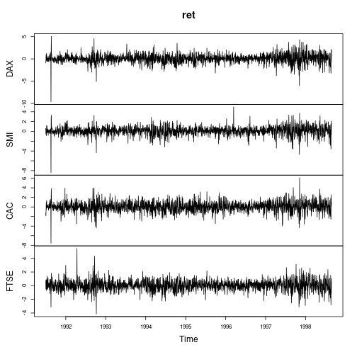

```r
ret <- diff(log(EuStockMarkets)) * 100
plot(ret)
```

The summary metrics of the returns are similar (not as extreme) as in OP's post.

```r
library(LambertW)  # this will load the `moments` package as well
data_metrics <- function(x) {
  c(mean = mean(x), sd = sd(x), min = min(x), max = max(x),
    skewness = skewness(x), kurtosis = kurtosis(x))
}
ret.metrics <- t(apply(ret, 2, data_metrics))
ret.metrics
```

```
##        mean    sd   min  max skewness kurtosis
## DAX  0.0652 1.030 -9.63 5.08   -0.554     9.28
## SMI  0.0818 0.925 -8.38 4.97   -0.632     8.74
## CAC  0.0437 1.103 -7.58 6.10   -0.177     5.39
## FTSE 0.0432 0.796 -4.14 5.44    0.110     5.64
```

Most series show clearly non-Normal characteristics (strong skewness and/or large kurtosis). Let's Gaussianize each series using a heavy tailed Lambert W x Gaussian distribution (= Tukey's h) using a methods of moments estimator (`IGMM`).

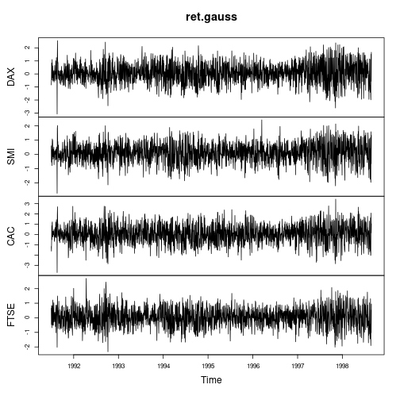

```r
library(LambertW)
ret.gauss <- Gaussianize(ret, type = "h", method = "IGMM")
colnames(ret.gauss) <- gsub("\\.X", "", colnames(ret.gauss))

plot(ret.gauss)
```

The time series plots show much fewer tails and also more stable variation over time (not constant though). Computing the metrics again on the Gaussianized time series yields:

```r
ret.gauss.metrics <- t(apply(ret.gauss, 2, data_metrics))
ret.gauss.metrics
```

```
##        mean    sd   min  max skewness kurtosis
## DAX  0.0718 0.797 -3.07 2.55 -0.07109        3
## SMI  0.0921 0.720 -2.74 2.42 -0.14035        3
## CAC  0.0463 0.948 -3.70 3.43 -0.04319        3
## FTSE 0.0431 0.681 -2.33 2.70 -0.00439        3
```

The `IGMM` algorithm achieved exactly what it was set forth to do: transform the data to have kurtosis equal to \(3\). Interestingly, all time series now have negative skewness, which is in line with most financial time series literature. Important to point out here that `Gaussianize()` operates only marginally, not jointly (analogously to `scale()`).

## Simple bivariate regression

To consider the effect of Gaussianization on OLS consider predicting “FTSE” return from “DAX” returns and vice versa.

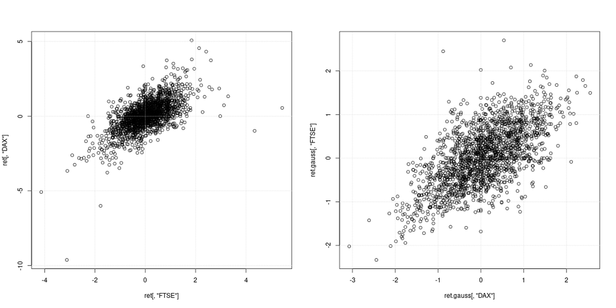

```r
layout(matrix(1:2, ncol = 2, byrow = TRUE))
plot(ret[, "FTSE"], ret[, "DAX"])
grid()
plot(ret.gauss[, "DAX"], ret.gauss[, "FTSE"])
grid()
```

```r
# try these models on your own
mod <- lm(FTSE ~ DAX + SMI + CAC, data = ret)
mod.robust <- rlm(FTSE ~ DAX + SMI + CAC, data = ret)
mod.gauss <- lm(FTSE ~ DAX + SMI + CAC, data = ret.gauss)

summary(mod)
summary(mod.robust)
summary(mod.gauss)
```

## Granger causality

```r
library(vars)
mod.vars <- vars::VAR(ret[, c("DAX", "CAC")], p = 6)
causality(mod.vars, "DAX")$Granger
```

```
##
##  Granger causality H0: DAX do not Granger-cause CAC
##
## data:  VAR object mod.vars
## F-Test = 2, df1 = 6, df2 = 3680, p-value = 0.09
```

```r
causality(mod.vars, "CAC")$Granger
```

```
##
##  Granger causality H0: CAC do not Granger-cause DAX
##
## data:  VAR object mod.vars
## F-Test = 0.9, df1 = 6, df2 = 3680, p-value = 0.5
```

```r
mod.vars.gauss <- vars::VAR(ret.gauss[, c("DAX", "CAC")], p = 6)
causality(mod.vars.gauss, "DAX")$Granger
```

```
##
##  Granger causality H0: DAX do not Granger-cause CAC
##
## data:  VAR object mod.vars.gauss
## F-Test = 0.9, df1 = 6, df2 = 3680, p-value = 0.5
```

```r
causality(mod.vars.gauss, "CAC")$Granger
```

```
##
##  Granger causality H0: CAC do not Granger-cause DAX
##
## data:  VAR object mod.vars.gauss
## F-Test = 0.9, df1 = 6, df2 = 3680, p-value = 0.5
```

It is not clear to me which one is the *right* answer (if any), but it's an interesting observation to make. Needless to say that this entire Causality testing is contingent on the \(VAR(6)\) being the correct model – which it is most likely not; but I think it serves well for illustratiton.